# Multivariate Paired Hotelling T Square Test

Author

Clay Ford

## Read in Data

First read in SPSS data and reshape to “wide” format.

```r
library(haven) # for read_sav() function
library(tidyr) # for pivot_wider() function
d <- read_sav("Full Blind Scores.sav")

# add subject id numbers
d$id <- rep(1:11, 2)

# reshape "wide" so there is a column for with and without tactor shirt
d_wide <- pivot_wider(d, names_from = Group,
                       values_from = MentalDemand:Diagonal_Accuracy)
```

## Multivariate Paired Hotelling T Square Test

To analyze this data I think we should use the Multivariate Paired Hotelling T Square Test. This is a multivariate version of the paired t test. Instead of comparing one set of pairs, we compare multiple sets of pairs. This [page at Penn State](https://online.stat.psu.edu/stat505/lesson/7/7.1/7.1.8) presents a nice overview of Multivariate Paired Hotelling T Square Test. Their example uses husband-wife pairs, but it applies to your pairs as well.

To implement this in R, we can use the `Mpaired()` function on the {MVTests} package. We need to create two separate data frames:

1. One with the first measures
2. One with the second measures

```r
library(MVTests)
X <- d_wide[,c("Straight_Time_1", "Straight_Accuracy_1", "Side_Time_1",
                "Side_Accuracy_1", "Diagonal_Time_1", "Diagonal_Accuracy_1")]
Y <- d_wide[,c("Straight_Time_2", "Straight_Accuracy_2", "Side_Time_2",
                "Side_Accuracy_2", "Diagonal_Time_2", "Diagonal_Accuracy_2")]
```

Then we use the `Mpaired()` function on the two data frames. Save the result and use `summary()` to see test result

```r
result <- Mpaired(T1 = X,T2 = Y)
summary(result)
```

```
       Multivariate Paired Hotelling T Square Test

Hotelling T Sqaure Statistic = 31.10435
 F value = 2.592 , df1 = 6 , df2 = 5 , p-value: 0.158

           Descriptive Statistics (The First Treatment)

      Straight_Time_1 Straight_Accuracy_1 Side_Time_1 Side_Accuracy_1
Means        20.82939            5.393939    21.20788        4.712121
Sd           15.27299            4.248707    18.81130        2.623707
      Diagonal_Time_1 Diagonal_Accuracy_1
Means        29.78667            4.424242
Sd           20.99498            4.274188


           Descriptive Statistics (The Second Treatment)

      Straight_Time_2 Straight_Accuracy_2 Side_Time_2 Side_Accuracy_2
Means        8.825758            42.01515    8.517273        44.89394
Sd           5.975533            46.25284    4.479820        45.56456
      Diagonal_Time_2 Diagonal_Accuracy_2
Means       10.250606            46.92424
Sd           6.063614            44.67956


           Descriptive Statistics (The Differences)

      Straight_Time_2 Straight_Accuracy_2 Side_Time_2 Side_Accuracy_2
Means       -12.00364            36.62121   -12.69061        40.18182
Sd           13.95356            46.18995    16.94681        44.53397
      Diagonal_Time_2 Diagonal_Accuracy_2
Means       -19.53606            42.50000
Sd           20.63703            43.00762
```

The null hypothesis is no difference in the differences. With a p-value of 0.16, we fail to find sufficient evidence to reject this hypothesis. This is not surprising given we are testing 6 sets of differences based on only 11 subjects.

## How to implement in SPSS

We can implement this in SPSS using the MANOVA routine, but we need to do two things first:

1. compute the differences in each set (Straight_Time_1 - Straight_Time_2, Straight_Accuracy_1 - Straight_Accuracy_2, etc)
2. Manually add an *intercept* to the data, which is just a column of ones.

Once that’s done, open the MANOVA (Multivariate) dialog and add the differences to the Dependent variables field and add the intercept to the Covariates Field.

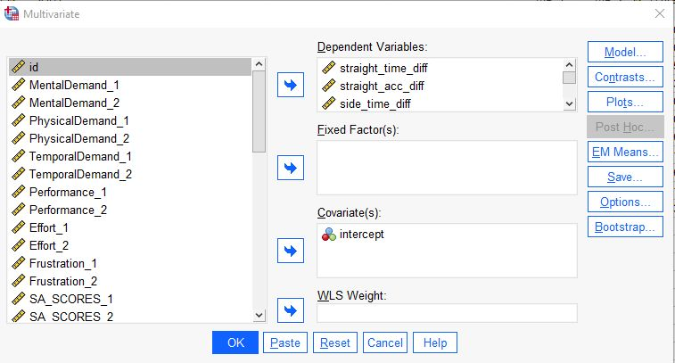

Next click the Model button, click the Build Terms radio button, add Intercept to the Model field, and uncheck the “Include intercept in model” box.

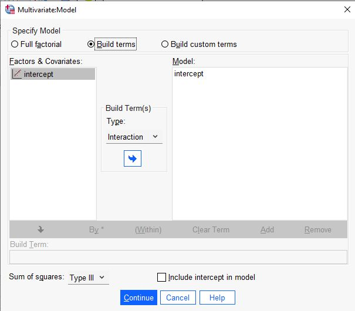

Click continue and click OK. The result is presented under the Multivariate Tests section as “Hotelling’s Trace.” This replicates the R output above.